# Final Project DS4100

Nicholas Chakmakas

#### Dataset source: https://data.world/sports/ncaa-mens-march-madness

### Problem:

We want to create a model to determine the winner of a March Madness game, given the matchup and seeding.

March Madness is broken up into 4 regions, each with 16 teams, seeded 1 through 16. Every first matchup is the same. Then, the winner of each region then moves on to play in semifinals. The winners of those games plays in the championship game. A single region is pictured below:

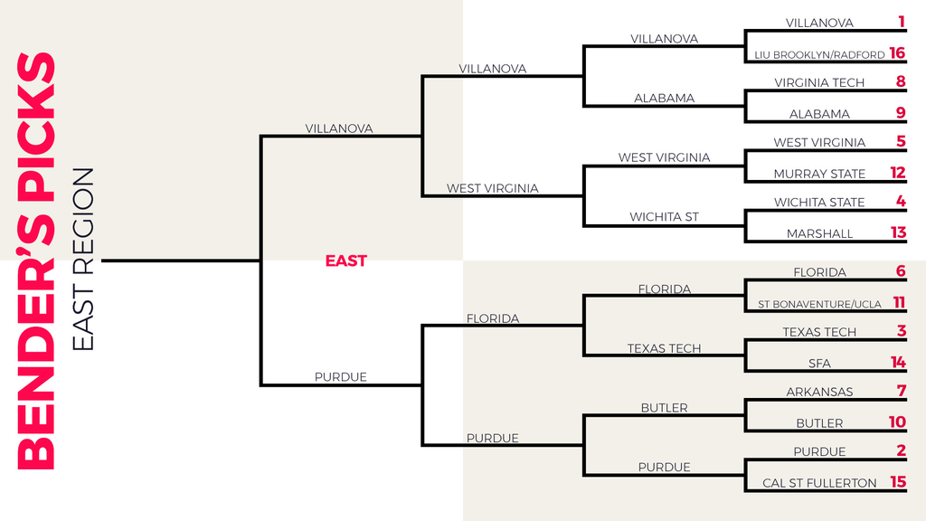

```r
library(tidyr)
library(dplyr)
library(aod)
library(ggplot2)
library(caret)
library(e1071)
library(lubridate)
library(RSQLite)
library(cowplot)
library(randomForest)
# Import the dataset showing tournament results. Our data contains
# the winners and losers of the tournament from 1985 to 2016, along with
# the winner's and loser's seeding. We must include every game to get
# a true representation (no outliers, since seed numbers are always 1-16)
tournamentData <- read.csv("NCAA Mens March Madness Historical Results.csv")
tournamentData$Date <- as.Date(tournamentData$Date, '%m/%d/%Y')
tournamentData$Year <- year(tournamentData$Date)
# Since we want to predict the winning seed, we have to make new data derived
# from our data set, since Winning seed and losing seed is only determined once
# a game has already taken place. So, we add HigherSeed and LowerSeed
# columns to represent the higher and lower seed matchup for each game, which
# is determined before the start of the game. We do the same for each team,
# since we do not know the winner and the loser before the start of the game.
# So new columns are added representing the favorited and unfavorited teams
# based off seeding.
tournamentData$HigherSeed[tournamentData$Winning.Seed > tournamentData$Losing.Seed] <-
  tournamentData$Losing.Seed[tournamentData$Winning.Seed > tournamentData$Losing.Seed]
tournamentData$HigherSeed[tournamentData$Winning.Seed < tournamentData$Losing.Seed] <-
  tournamentData$Winning.Seed[tournamentData$Winning.Seed < tournamentData$Losing.Seed]
tournamentData$HigherSeed[tournamentData$Winning.Seed == tournamentData$Losing.Seed] <-
  tournamentData$Winning.Seed[tournamentData$Winning.Seed == tournamentData$Losing.Seed]
tournamentData$LowerSeed[tournamentData$Winning.Seed > tournamentData$Losing.Seed] <-
  tournamentData$Winning.Seed[tournamentData$Winning.Seed > tournamentData$Losing.Seed]
tournamentData$LowerSeed[tournamentData$Winning.Seed < tournamentData$Losing.Seed] <-
  tournamentData$Losing.Seed[tournamentData$Winning.Seed < tournamentData$Losing.Seed]
tournamentData$LowerSeed[tournamentData$Winning.Seed == tournamentData$Losing.Seed] <-
  tournamentData$Winning.Seed[tournamentData$Winning.Seed == tournamentData$Losing.Seed]
tournamentData$FavoritedTeam[tournamentData$Winning.Seed < tournamentData$Losing.Seed] <-
  as.character(tournamentData$Winner[tournamentData$Winning.Seed < tournamentData$Losing.Seed])
tournamentData$FavoritedTeam[tournamentData$Winning.Seed > tournamentData$Losing.Seed] <-
  as.character(tournamentData$Loser[tournamentData$Winning.Seed > tournamentData$Losing.Seed])
tournamentData$FavoritedTeam[tournamentData$Winning.Seed == tournamentData$Losing.Seed] <-
  as.character(tournamentData$Winner[tournamentData$Winning.Seed == tournamentData$Losing.Seed])
tournamentData$UnfavoritedTeam[tournamentData$Winning.Seed == tournamentData$Losing.Seed] <-
  as.character(tournamentData$Loser[tournamentData$Winning.Seed == tournamentData$Losing.Seed])
tournamentData$UnfavoritedTeam[tournamentData$Winning.Seed > tournamentData$Losing.Seed] <-
  as.character(tournamentData$Winner[tournamentData$Winning.Seed > tournamentData$Losing.Seed])
tournamentData$UnfavoritedTeam[tournamentData$Winning.Seed < tournamentData$Losing.Seed] <-
  as.character(tournamentData$Loser[tournamentData$Winning.Seed < tournamentData$Losing.Seed])
# We do not need overtime, or scores, because we are looking at the matchup
# before the result is determined. So having the scores of the game after the
# fact are not needed, as well as if the game went into overtime. Remove these
# columns from the data set.
tournamentData$Winning.Score <- NULL
tournamentData$Losing.Score <- NULL
tournamentData$Overtime <- NULL
# Create column showing whether match resulted in upset or not; an upset
# is defined as the winning seed being at least 3 seeds lower than the
# losing seed (i.e. a 10 seed beating a 7 seed, or a 10 seed beating a 1 seed)
# If seeds are not at least 3 apart in distance (i.e. 9 seed beating 8 seed)
# it is not considered an upset.
tournamentData$isUpset[tournamentData$Winning.Seed - tournamentData$Losing.Seed >= 3] <- 1
tournamentData$isUpset[tournamentData$Winning.Seed - tournamentData$Losing.Seed < 3] <- 0
```

```r
# Put the table we created into a SQLite database
db <- dbConnect(RSQLite::SQLite(),
                     "marchMadnessData.sqlite")
dbWriteTable(db, "marchMadnessData", tournamentData, overwrite = TRUE)
```

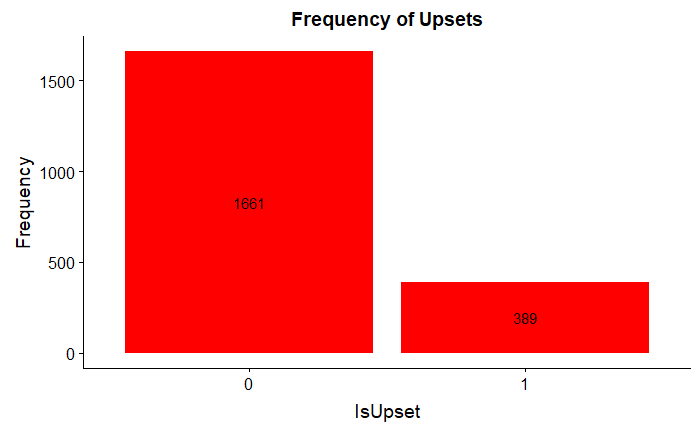

```r
# SQL query for getting the number of times each seed has won / lost
# its respective game. This information is then stored in a data frame,
# which is returned by the function.
getFreqTable <- function(x) {

  # Function runs query on dataset. Complex join query, since
  # SQLite does not support full outer join.

  result <- data.frame(dbGetQuery(db, paste("with winningSeedFreq(seed, winFreq) as
(select [Winning.Seed], count([Winning.Seed])
           from marchMadnessData
           where (Round = '", x, "')
           group by [Winning.Seed]),
           losingSeedFreq(seed, loseFreq) as
           (select [Losing.Seed], count([Losing.Seed])
           from marchMadnessData
           where (Round = '", x, "')
           group by [Losing.Seed])

           SELECT winningSeedFreq.Seed, winningSeedFreq.winFreq, losingSeedFreq.loseFreq
            FROM winningSeedFreq
           LEFT JOIN losingSeedFreq USING(seed)
           UNION ALL
           SELECT losingSeedFreq.Seed, winningSeedFreq.winFreq, losingSeedFreq.loseFreq
           FROM losingSeedFreq
           LEFT JOIN winningSeedFreq USING(seed)
           WHERE winningSeedFreq.seed IS NULL;", sep = "")))

  result$seed <- as.numeric(result$seed)
  result$winFreq <- as.numeric(result$winFreq)
  result$loseFreq <- as.numeric(result$loseFreq)

  # Simple solution for handling NA in data. This simply means there is a
  # null value returned by the joining of the tables, so this will be a zero
  # since the value would be returned if there were any wins/losses.
  result[is.na(result)] <- 0
  result[order(result$seed),]
}
roundOf64 <- getFreqTable("Round of 64")
roundOf32 <- getFreqTable("Round of 32")
roundOf16 <- getFreqTable("Sweet Sixteen")
eliteEight <- getFreqTable("Elite Eight")
finalFour <- getFreqTable("National Semifinals")
championship <- getFreqTable("National Championship")
# This function will help us visualize the number of times
# each seed number has lost / won its respective game. We expect
# the higher seeds to have won more games than the lower seeds.
plotFrequencies <- function(x, title) {
  result <-
  data.frame(c(x$seed, x$seed), c(rep("# of wins", length(x$seed)),
  rep("# of losses", length(x$seed))),
  c(x$winFreq, x$loseFreq))

  colnames(result) <- c("Seed", "FrequencyType", "Count")

  ggplot(result, aes(x = Seed, y = Count, fill = FrequencyType)) +
    geom_bar(position = position_dodge2(reverse = TRUE), stat = "identity") +
    scale_x_discrete("Seed",
  labels = as.character(result$Seed),
  limits = result$Seed) + ggtitle(title)
}
# Show frequency of how often an upset occurs
upsetsDf <- as.data.frame(table(tournamentData$isUpset))
colnames(upsetsDf) <- c("IsUpset", "Frequency")
ggplot(upsetsDf, aes(x=IsUpset, y = Frequency, label = Frequency)) +
  geom_bar(stat="identity", fill = "Red") +
  ggtitle("Frequency of Upsets") +
  geom_text(position = position_stack(vjust = .5))
```

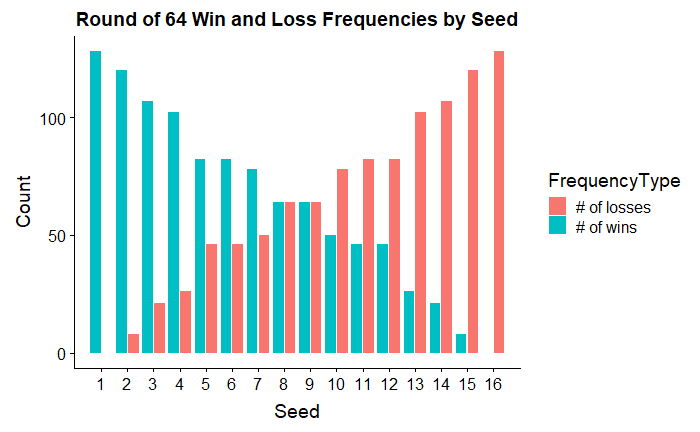

```r
plotFrequencies(roundOf64, "Round of 64 Win and Loss Frequencies by Seed")
```

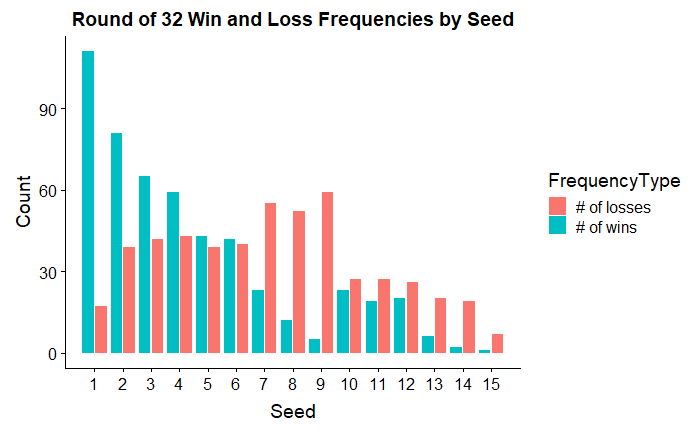

```r
plotFrequencies(roundOf32, "Round of 32 Win and Loss Frequencies by Seed")
```

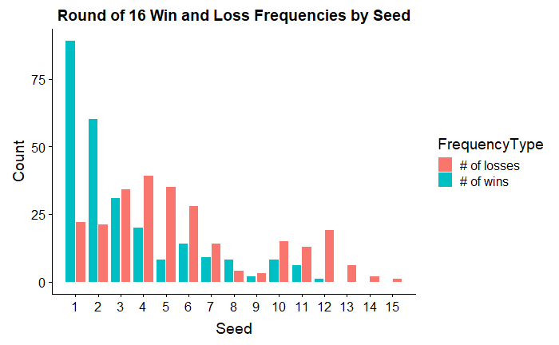

```r
plotFrequencies(roundOf16, "Round of 16 Win and Loss Frequencies by Seed")
```

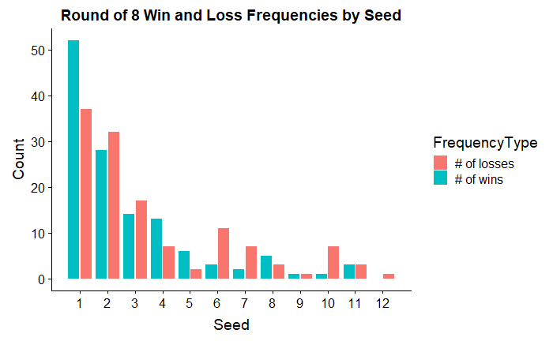

```r
plotFrequencies(eliteEight, "Round of 8 Win and Loss Frequencies by Seed")
```

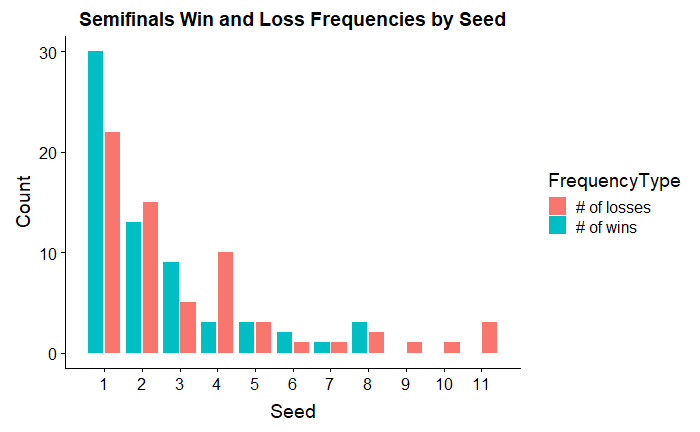

```r
plotFrequencies(finalFour, "Semifinals Win and Loss Frequencies by Seed")
```

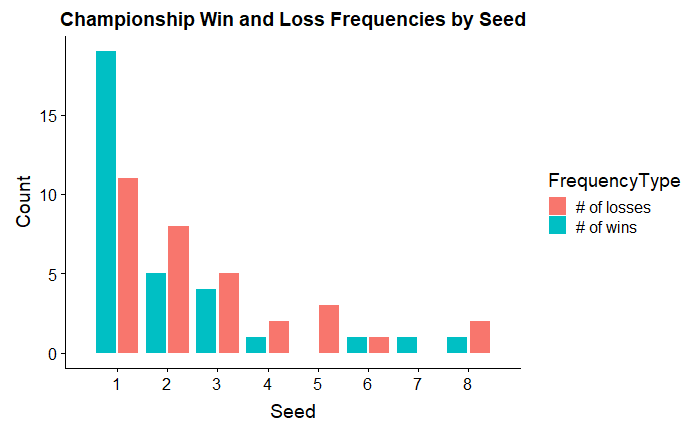

```r
plotFrequencies(championship, "Championship Win and Loss Frequencies by Seed")
```

```r
# Set all columns regarding seeding to factors with levels 1-16
tournamentData$Winning.Seed <- as.factor(tournamentData$Winning.Seed)
levels(tournamentData$Winning.Seed) <-
  c(1, 2, 3, 4, 5, 6, 7, 8, 9, 10, 11, 12, 13, 14, 15, 16)
tournamentData$HigherSeed <- as.factor(tournamentData$HigherSeed)
levels(tournamentData$HigherSeed) <-
  c(1, 2, 3, 4, 5, 6, 7, 8, 9, 10, 11, 12, 13, 14, 15, 16)
tournamentData$Losing.Seed <- as.factor(tournamentData$Losing.Seed)
levels(tournamentData$Losing.Seed) <-
  c(1, 2, 3, 4, 5, 6, 7, 8, 9, 10, 11, 12, 13, 14, 15, 16)
tournamentData$LowerSeed <- as.factor(tournamentData$LowerSeed)
levels(tournamentData$LowerSeed) <-
  c(1, 2, 3, 4, 5, 6, 7, 8, 9, 10, 11, 12, 13, 14, 15, 16)
# Split data into 70% training data set and 30% test data set.
# Model will be built with training_data, and the
# test_data will test the model's accuracy.
training_data <- tournamentData %>% sample_frac(0.7)
test_data <- setdiff(tournamentData, training_data)
```

```r
# We will use naive bayes to create our model. Since we want to predict
# the winning seed, we cannot use any of the data involving who the winner /
# loser is, since that is determined after the match has ended.
# Let's try the following two variables and evaulate the model:
# HigherSeed and LowerSeed
bballModel <- naiveBayes(Winning.Seed ~ HigherSeed + LowerSeed,
                         data = training_data)
prediction <- predict(bballModel, test_data)
```

```
NAs introduced by coercionNAs introduced by coercion
```

```r
modelMatrix <- confusionMatrix(prediction, test_data$Winning.Seed)
modelMatrix #ConfusionMatrix used for measuring accuracy
```

```
Confusion Matrix and Statistics

          Reference
Prediction   1   2   3   4   5   6   7   8   9  10  11  12  13  14  15  16
        1  420  29  12  17   7   3   0  13   5   1   3   0   0   0   0   0
        2    5 275  18   4   0   7  22   0   0  18   1   0   0   0   8   0
        3    0   0 199   3   1  28   5   0   0   4  14   0   0  21   0   0
        4    4   0   0 170  31   2   2   5   1   0   0  12  27   0   0   0
        5    0   1   0   0 102   0   0   2   0   0   0  47   3   0   0   0
        6    0   0   0   0   0 104   3   0   0   2  46   0   0   2   0   0
        7    0   0   0   2   0   0  79   1   0  50   0   0   0   0   0   0
        8    0   2   0   2   1   0   0   8   2   0   0   0   0   0   0   0
        9    0   0   0   0   0   0   0  64  64   0   0   0   0   0   0   0
        10   0   0   1   0   0   0   3   0   0   6   3   0   0   0   1   0
        11   0   0   0   0   0   0   0   0   0   1  14   0   0   0   0   0
        12   0   0   0   0   0   0   0   0   0   0   0   3   0   0   0   0
        13   0   0   0   0   0   0   0   0   0   0   0   8   3   0   0   0
        14   0   0   0   0   0   0   0   0   0   0   0   0   0   1   0   0
        15   0   0   0   0   0   0   0   0   0   0   0   0   0   0   0   0
        16   0   0   0   0   0   0   0   0   0   0   0   0   0   0   0  22

Overall Statistics

               Accuracy : 0.7171
                 95% CI : (0.697, 0.7365)
    No Information Rate : 0.2093
    P-Value [Acc > NIR] : < 2.2e-16

                  Kappa : 0.6775
 Mcnemar's Test P-Value : NA

Statistics by Class:

                     Class: 1 Class: 2 Class: 3 Class: 4 Class: 5 Class: 6 Class: 7 Class: 8 Class: 9 Class: 10 Class: 11 Class: 12 Class: 13 Class: 14 Class: 15 Class: 16
Sensitivity            0.9790   0.8958  0.86522  0.85859  0.71831  0.72222  0.69298 0.086022  0.88889  0.073171  0.172840  0.042857  0.090909 0.0416667   0.00000   1.00000
Specificity            0.9445   0.9524  0.95824  0.95464  0.97222  0.97219  0.97262 0.996423  0.96764  0.995935  0.999492  1.000000  0.996034 1.0000000   1.00000   1.00000
Pos Pred Value         0.8235   0.7682  0.72364  0.66929  0.65806  0.66242  0.59848 0.533333  0.50000  0.428571  0.933333  1.000000  0.272727 1.0000000       NaN   1.00000
Neg Pred Value         0.9942   0.9811  0.98254  0.98441  0.97889  0.97887  0.98175 0.958231  0.99584  0.962672  0.967076  0.967269  0.985287 0.9887750   0.99561   1.00000
Prevalence             0.2093   0.1498  0.11220  0.09659  0.06927  0.07024  0.05561 0.045366  0.03512  0.040000  0.039512  0.034146  0.016098 0.0117073   0.00439   0.01073
Detection Rate         0.2049   0.1341  0.09707  0.08293  0.04976  0.05073  0.03854 0.003902  0.03122  0.002927  0.006829  0.001463  0.001463 0.0004878   0.00000   0.01073
Detection Prevalence   0.2488   0.1746  0.13415  0.12390  0.07561  0.07659  0.06439 0.007317  0.06244  0.006829  0.007317  0.001463  0.005366 0.0004878   0.00000   0.01073
Balanced Accuracy      0.9617   0.9241  0.91173  0.90661  0.84527  0.84721  0.83280 0.541222  0.92827  0.534553  0.586166  0.521429  0.543471 0.5208333   0.50000   1.00000
```

```r
# Let's try adding teams, and see if that gives us a stronger accuracy
# for the model.
bballModel <- naiveBayes(Winning.Seed ~ HigherSeed + LowerSeed + FavoritedTeam
                         + UnfavoritedTeam,
                         data = training_data)
prediction <- predict(bballModel, test_data)
modelMatrix <- confusionMatrix(prediction, test_data$Winning.Seed)
modelMatrix
```

```
Confusion Matrix and Statistics

          Reference
Prediction   1   2   3   4   5   6   7   8   9  10  11  12  13  14  15  16
        1  413  29  10  17   7   2   1   8   3   1   0   0   0   0   0   0
        2    4 258  18   4   0   7  11   0   0   4   1   0   0   0   1   0
        3    0   0 179   2   1  19   1   1   0   1   4   0   0   6   0   0
        4    3   1   0 158  14   1   1   2   0   0   0   1   9   0   0   0
        5    3   0   0   5 112   0   0   1   0   0   0  15   1   0   0   0
        6    0   2   3   0   0  92   1   0   0   1   8   0   0   1   0   0
        7    1   7   4   1   0   0  82   1   0  12   0   0   0   0   1   0
        8    3   1   0   0   0   0   0  61  12   0   0   0   0   0   0   0
        9    1   0   0   1   1   0   0  19  56   0   0   0   0   0   0   0
        10   0   7   2   0   0   1  16   0   0  62   2   0   0   0   0   0
        11   1   0  10   0   0  18   0   0   0   1  66   0   0   0   0   0
        12   0   1   0   6   6   0   0   0   0   0   0  51   0   0   0   0
        13   0   0   0   4   1   0   0   0   1   0   0   3  23   0   0   0
        14   0   0   4   0   0   4   1   0   0   0   0   0   0  17   0   0
        15   0   1   0   0   0   0   0   0   0   0   0   0   0   0   7   0
        16   0   0   0   0   0   0   0   0   0   0   0   0   0   0   0  22

Overall Statistics

               Accuracy : 0.8093
                 95% CI : (0.7916, 0.8261)
    No Information Rate : 0.2093
    P-Value [Acc > NIR] : < 2.2e-16

                  Kappa : 0.785
 Mcnemar's Test P-Value : NA

Statistics by Class:

                     Class: 1 Class: 2 Class: 3 Class: 4 Class: 5 Class: 6 Class: 7 Class: 8 Class: 9 Class: 10 Class: 11 Class: 12 Class: 13 Class: 14 Class: 15 Class: 16
Sensitivity            0.9627   0.8404  0.77826  0.79798  0.78873  0.63889  0.71930  0.65591  0.77778   0.75610   0.81481   0.72857   0.69697  0.708333  0.777778   1.00000
Specificity            0.9519   0.9713  0.98077  0.98272  0.98690  0.99161  0.98605  0.99182  0.98888   0.98577   0.98476   0.99343   0.99554  0.995558  0.999510   1.00000
Pos Pred Value         0.8411   0.8377  0.83645  0.83158  0.81752  0.85185  0.75229  0.79221  0.71795   0.68889   0.68750   0.79688   0.71875  0.653846  0.875000   1.00000
Neg Pred Value         0.9897   0.9719  0.97222  0.97849  0.98432  0.97322  0.98351  0.98378  0.99189   0.98980   0.99232   0.99043   0.99504  0.996542  0.999021   1.00000
Prevalence             0.2093   0.1498  0.11220  0.09659  0.06927  0.07024  0.05561  0.04537  0.03512   0.04000   0.03951   0.03415   0.01610  0.011707  0.004390   0.01073
Detection Rate         0.2015   0.1259  0.08732  0.07707  0.05463  0.04488  0.04000  0.02976  0.02732   0.03024   0.03220   0.02488   0.01122  0.008293  0.003415   0.01073
Detection Prevalence   0.2395   0.1502  0.10439  0.09268  0.06683  0.05268  0.05317  0.03756  0.03805   0.04390   0.04683   0.03122   0.01561  0.012683  0.003902   0.01073
Balanced Accuracy      0.9573   0.9059  0.87952  0.89035  0.88781  0.81525  0.85268  0.82387  0.88333   0.87093   0.89979   0.86100   0.84625  0.851946  0.888644   1.00000
```